# Stats Project

Luke Anderson, Jeremy Earnst, and Ryan Smith

3/21/2022

# March Madness Final Project

## Rough Draft

#### Luke Anderson, Jeremy Earnst, Ryan Smith

## Abstract

Using data from Bart Torvik’s T-Rank website and college basketball ratings system, we analyze the impact of different regular season metrics on March Madness tournament success during the 2020-2021 college basketball season. We incorporate different statistical methods into our analysis, including graphical representation, summary statistics, correlations, and linear regression models. We find that it is actually quite hard to predict tournament success based on these metrics: we find that only barthag rating, tournament seed, expected wins, offensive and defensive efficiency, and EFG and EFGD % are significant predictors of tournament wins (and it’s worth noting that some of these metrics may be linearly dependent upon one another). Other variables (like a team’s turnover rate and offensive rebounding) seem to have a significant impact on a team’s probability of making the tournament, but beyond these the other results that we find in this category are bogged down by modeling issues, making it hard to be sure of the conclusions.

From all of this, we can anticlimactically conclude that having a good offense and a good defense helps teams have more tournament success. However, in our work we were able to helpfully debunk the myth that strength of schedule and offensive tempo are significant factors in tournament success, a result which may surprise most college basketball fans. Finally, we note that our own created metric of “expected wins” was a very good predictor of tournament success, and we hope that such a discovery could be used in the future as a contribution to the world of sports statistics.

## Introduction

March Madness is a knockout style tournament in which 64 college basketball teams compete to be the US national champions. The tournament, taking place annually during the titular month of March, draws millions of viewers and over a billion dollars in revenue each year. With all those eyes and all those dollars, everyone is looking for a way to gain an edge on the tournaments results. Whether it’s teams trying to outsmart the competition, bookies working to set odds, or an average Joe trying to find the perfect bracket, everyone wants to know what will happen. With the advent of “moneyball” and data driven sports, one of the many new approaches to predicting March Madness is statistical analysis. It is into this world that we step as we analyze data from the 2021 college basketball season.

(NOTE: For simplicity, we have removed the four teams that lost in the play-in games from the tournament data.)

## EDA

First, we split the data into only tournament teams data and all teams data (but without the tournament results) to avoid NA errors.

Then we look at the correlations of some of the more important parameters.

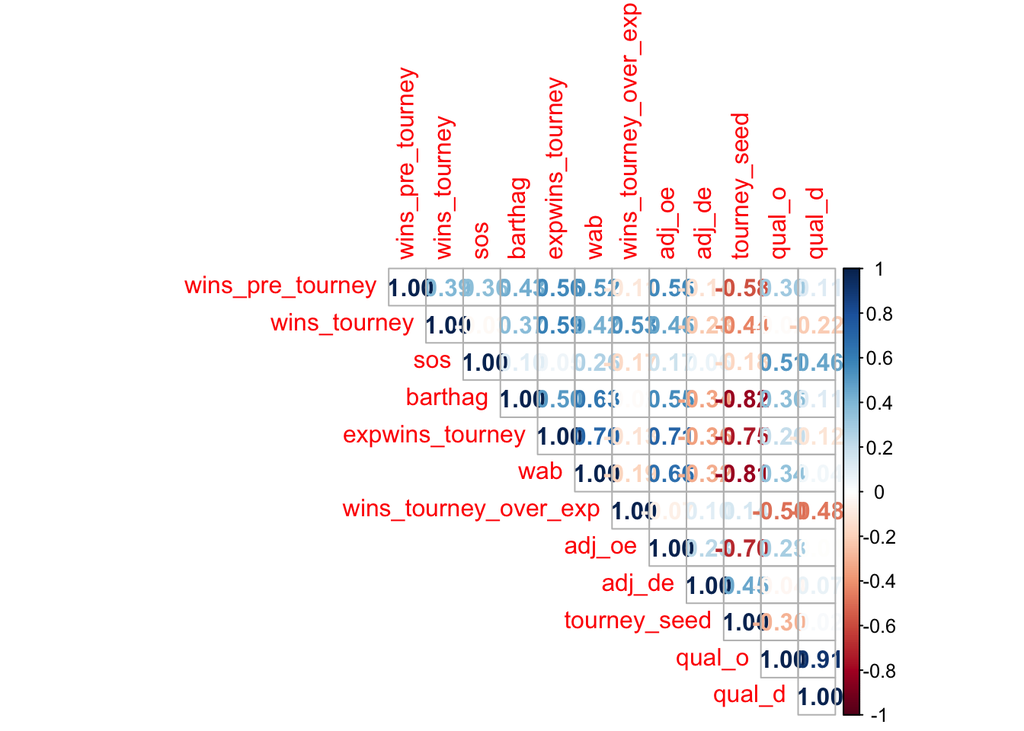

Some Notes: -We find a correlation of -0.823611515 between tourney_seed and barthag -We find a correlation of 0.629154972 between WAB and barthag (maybe barthag is used to calculate WAB?) -We find a correlation of 0.59456443 between wins_tourney and expwins_tourney -We find a correlation of 0.42345707 between WAB and wins_tourney -We find a correlation of 0.997141452 between tourney_seed and tourney_rank -We find no strong correlation between any variable and our created variable, wins_tourney_over_exp (metric for a team’s success).

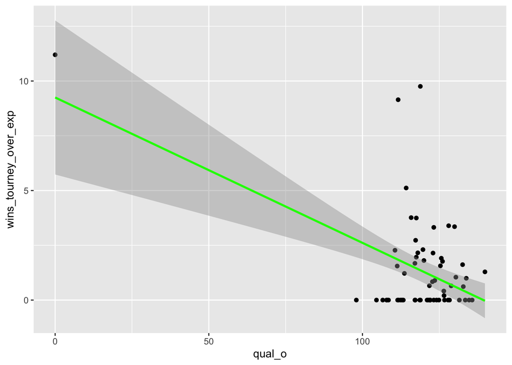

Looking at this graph shows us that a large portion of the values of our success metric are 0, while the rest show little to no pattern. This would obviously make it difficult to find a strong correlation.

Looking at how wins against bubble, one of the more strongly correlated parameters compares to tourney wins. Using both a simple linear model and one with a quadratic term.

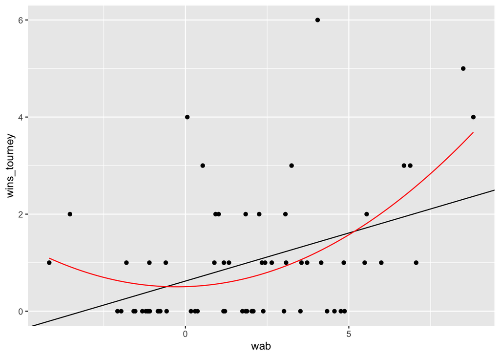

Plotting the residuals of the two models to compare them.

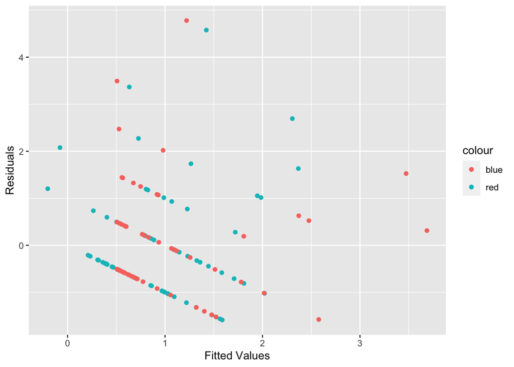

Plotting the residuals as a histogram to see their distributions. Here we can more clearly see that the simple linear model is a better model than the quadratic one.

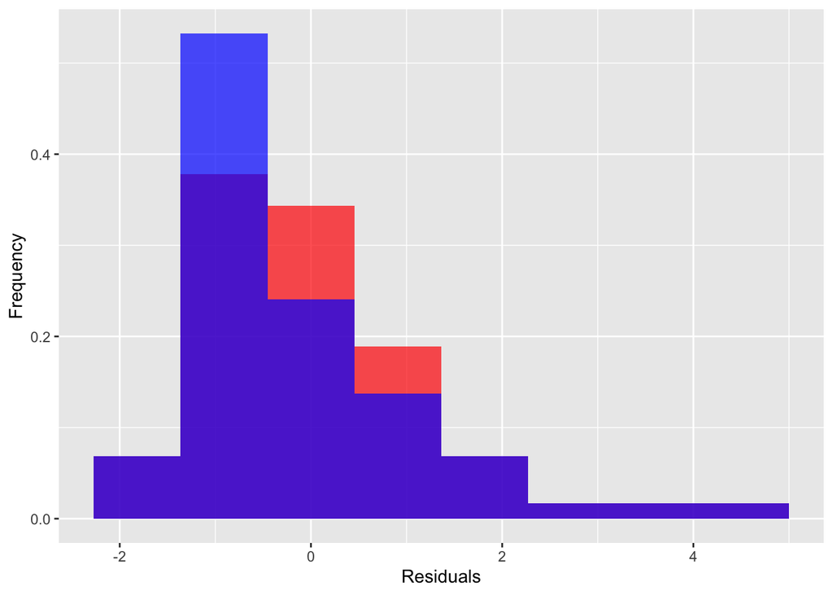

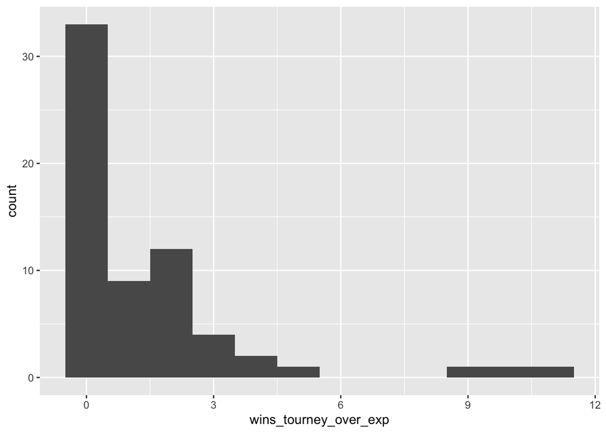

```
## # A tibble: 6 × 1
##   team
##   <chr>
## 1 Oral Roberts
## 2 UCLA
## 3 Oregon St.
## 4 Syracuse
## 5 USC
## 6 Abilene Christian
```

```
## # A tibble: 6 × 1
##   team
##   <chr>
## 1 Ohio St.
## 2 Texas
## 3 Virginia
## 4 Purdue
## 5 Tennessee
## 6 San Diego St.
```

Looking at tourney wins over expected wins, a ratio of actual to expected success. High values indicate that a team won many more games than they were expected to, this this metric acts as a measure for overperformance. Meanwhile, low values indicate underperformance.

Some graphs relating to the expected wins metric and how well it correlates with actual tourney wins:

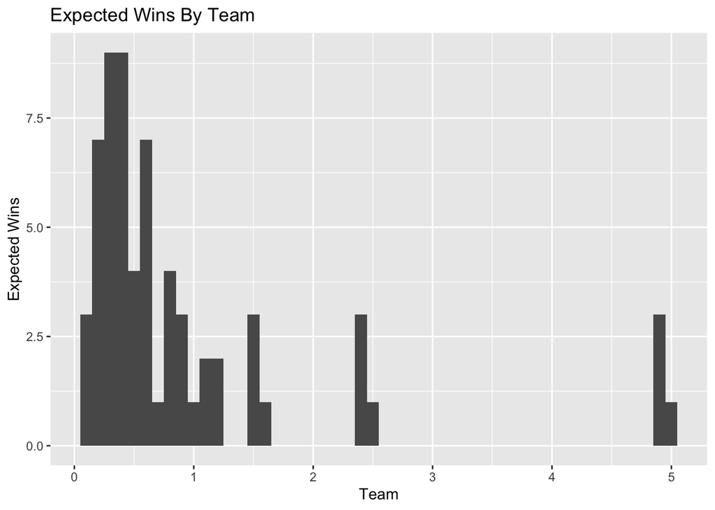

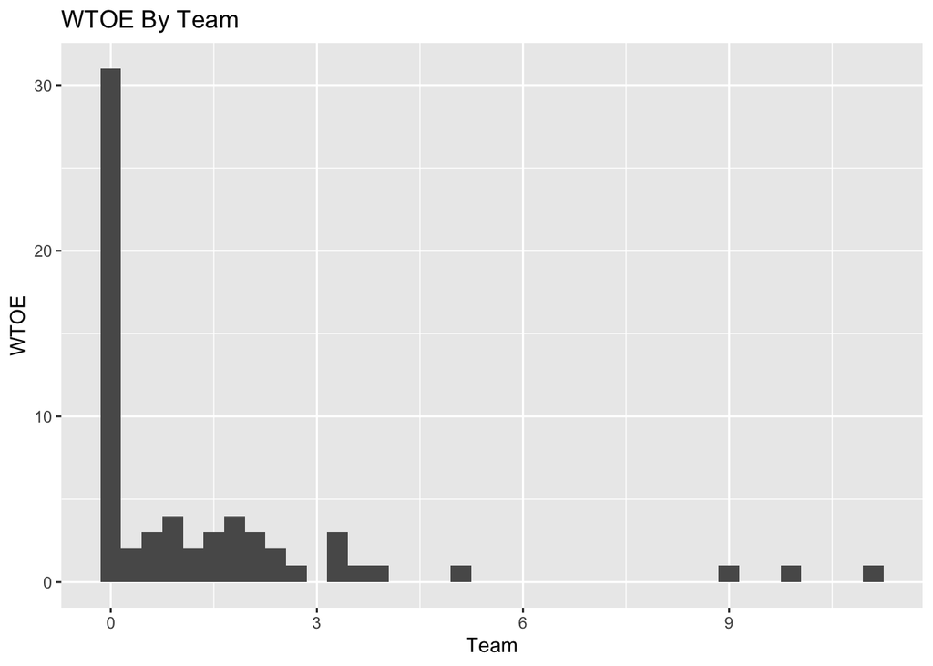

```
##      team               conf           wins_pre_tourney losses_pre_tourney
##  Length:64          Length:64          Min.   :12.00    Min.   : 0.000
##  Class :character   Class :character   1st Qu.:15.00    1st Qu.: 6.000
##  Mode  :character   Mode  :character   Median :18.00    Median : 7.000
##                                        Mean   :18.05    Mean   : 7.047
##                                        3rd Qu.:20.25    3rd Qu.: 9.000
##                                        Max.   :26.00    Max.   :13.000
##  totalgames_pre_tourney wins_post_tourney losses_post_tourney
##  Min.   :15.00          Min.   :12.00     Min.   : 1.000
##  1st Qu.:23.00          1st Qu.:16.00     1st Qu.: 7.000
##  Median :26.00          Median :19.00     Median : 8.000
##  Mean   :25.09          Mean   :19.08     Mean   : 8.016
##  3rd Qu.:27.00          3rd Qu.:21.25     3rd Qu.:10.000
##  Max.   :30.00          Max.   :31.00     Max.   :14.000
##  totalgames_post_tourney   wins_conf      losses_conf     totalgames_conf
##  Min.   :16.00           Min.   : 4.00   Min.   : 0.000   Min.   : 9.00
##  1st Qu.:25.00           1st Qu.:10.00   1st Qu.: 3.000   1st Qu.:15.00
##  Median :27.00           Median :11.00   Median : 5.000   Median :17.00
##  Mean   :27.09           Mean   :11.58   Mean   : 4.938   Mean   :16.52
##  3rd Qu.:30.00           3rd Qu.:14.00   3rd Qu.: 6.000   3rd Qu.:18.00
##  Max.   :33.00           Max.   :17.00   Max.   :11.000   Max.   :20.00
##   tourney_rank    tourney_seed    wins_tourney    expwins_tourney
##  Min.   : 1.00   Min.   : 1.00   Min.   :0.0000   Min.   :0.1136
##  1st Qu.:16.75   1st Qu.: 4.75   1st Qu.:0.0000   1st Qu.:0.3108
##  Median :32.50   Median : 8.50   Median :1.0000   Median :0.5386
##  Mean   :33.20   Mean   : 8.50   Mean   :0.9844   Mean   :0.9694
##  3rd Qu.:50.25   3rd Qu.:12.25   3rd Qu.:1.0000   3rd Qu.:0.9981
##  Max.   :67.00   Max.   :16.00   Max.   :6.0000   Max.   :5.0257
##  wins_tourney_over_exp    barthag        barthag_rank        ...19
##  Min.   : 0.0000       Min.   :0.3542   Min.   :  1.00   Min.   :0.02214
##  1st Qu.: 0.0000       1st Qu.:0.7661   1st Qu.: 16.75   1st Qu.:0.06056
##  Median : 0.3085       Median :0.8706   Median : 34.00   Median :0.10496
##  Mean   : 1.3603       Mean   :0.8167   Mean   : 53.38   Mean   :0.18892
##  3rd Qu.: 1.8322       3rd Qu.:0.9121   3rd Qu.: 78.25   3rd Qu.:0.19450
##  Max.   :11.1975       Max.   :0.9794   Max.   :216.00   Max.   :0.97937
##      adj_oe        adjoe_rank         adj_de        adjde_rank
##  Min.   :101.7   Min.   :  1.00   Min.   :86.09   Min.   :  1.00
##  1st Qu.:108.3   1st Qu.: 16.75   1st Qu.:91.35   1st Qu.: 19.75
##  Median :110.9   Median : 37.50   Median :93.93   Median : 41.50
##  Mean   :111.6   Mean   : 43.58   Mean   :93.42   Mean   : 44.41
```

[output cut: 50 more lines]

```
##  Max.   :41.80   Max.   :42.40   Max.   :22.40   Max.   :24.60
##       ORB             DRB          twoP_perc       twoPD_perc
##  Min.   :19.50   Min.   :21.00   Min.   :45.50   Min.   :42.20
##  1st Qu.:28.27   1st Qu.:24.80   1st Qu.:49.30   1st Qu.:45.77
##  Median :30.60   Median :27.35   Median :51.90   Median :46.85
##  Mean   :30.40   Mean   :27.31   Mean   :51.49   Mean   :47.28
##  3rd Qu.:32.45   3rd Qu.:29.80   3rd Qu.:52.92   3rd Qu.:48.67
##  Max.   :41.30   Max.   :33.80   Max.   :64.00   Max.   :54.80
##   threeP_perc     threePD_perc        wab2
##  Min.   :28.40   Min.   :26.10   Min.   : 0.00327
##  1st Qu.:33.70   1st Qu.:31.70   1st Qu.: 1.32454
##  Median :35.10   Median :32.75   Median : 4.17580
##  Mean   :35.02   Mean   :32.76   Mean   :11.41041
##  3rd Qu.:36.52   3rd Qu.:34.10   3rd Qu.:14.48724
##  Max.   :41.80   Max.   :36.70   Max.   :77.60585
```

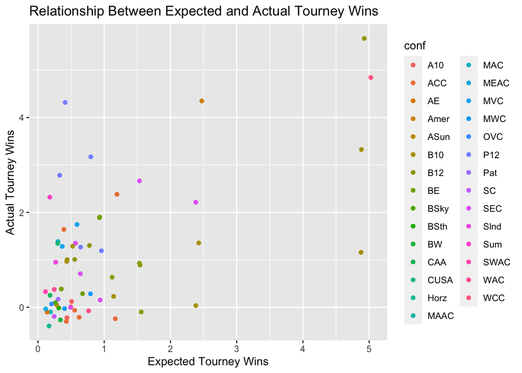

Breakdown of tournament wins over expected wins by conference:

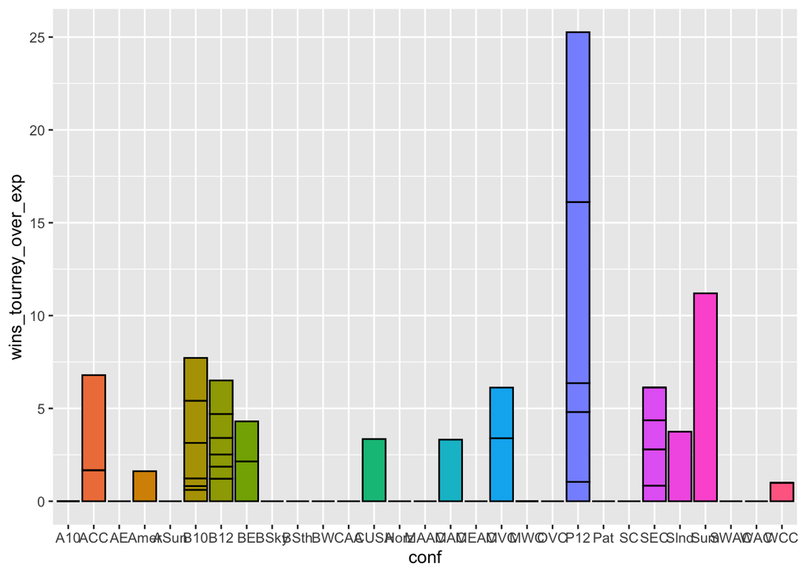

Breakdown of overall tournament wins by conference:

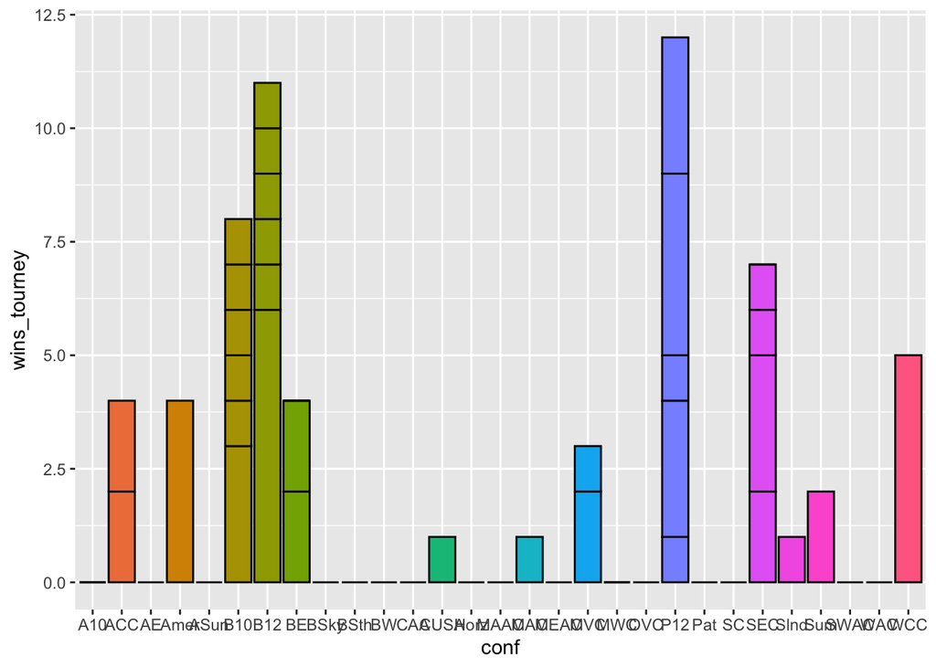

Looking at the the statistics broken down by conference allows us to further explore the possible influences of a team’s conference on its tournament results.

## Modeling

### Outcome: Tournament Wins

We will start simple, and regress the number of tourney wins on the team’s tourney seed:

```
##
## Call:
## lm(formula = wins_tourney ~ tourney_seed, data = CBBtourney)
##
## Residuals:
##     Min      1Q  Median      3Q     Max
## -1.8088 -0.7941 -0.1746  0.4766  4.0643
##
## Coefficients:
##              Estimate Std. Error t value Pr(>|t|)
## (Intercept)   2.06250    0.31784   6.489 1.63e-08 ***
## tourney_seed -0.12684    0.03287  -3.859 0.000274 ***
## ---
## Signif. codes:  0 '***' 0.001 '**' 0.01 '*' 0.05 '.' 0.1 ' ' 1
##
## Residual standard error: 1.212 on 62 degrees of freedom
## Multiple R-squared:  0.1937, Adjusted R-squared:  0.1806
## F-statistic: 14.89 on 1 and 62 DF,  p-value: 0.0002741
```

Here find a very low p-value, giving us strong reason to reject H0. From the regression we can say that improving a team’s seed by one unit would, on average, result in .12684 more wins in the tournament.

Next, we will regress the number of tourney wins on the team’s pre-tournament barthag:

```
##
## Call:
## lm(formula = wins_tourney ~ barthag, data = CBBtourney)
##
## Residuals:
##     Min      1Q  Median      3Q     Max
## -1.3556 -1.0298 -0.1952  0.5228  4.5403
##
## Coefficients:
##             Estimate Std. Error t value Pr(>|t|)
## (Intercept)  -1.7223     0.8769  -1.964  0.05402 .
## barthag       3.3141     1.0565   3.137  0.00261 **
## ---
## Signif. codes:  0 '***' 0.001 '**' 0.01 '*' 0.05 '.' 0.1 ' ' 1
##
## Residual standard error: 1.254 on 62 degrees of freedom
## Multiple R-squared:  0.137,  Adjusted R-squared:  0.1231
## F-statistic: 9.841 on 1 and 62 DF,  p-value: 0.00261
```

Once again, we find reason to reject H0, with a low p-value of .00261. This regression says that a .1 unit increase in pre-tourney barthag rating results in, on avergage, .33141 more wins in the tourney.

Next, let’s take a look at how good our expected tourney wins metric is at predicting actual tournament wins. Remember that this metric includes both seed and barthag in its formula, so we would expect it to have similar results to the first couple of regressions:

```
##
## Call:
## lm(formula = wins_tourney ~ expwins_tourney, data = CBBtourney)
##
## Residuals:
##     Min      1Q  Median      3Q     Max
## -2.6201 -0.6243 -0.4162  0.4333  3.3929
##
## Coefficients:
##                 Estimate Std. Error t value Pr(>|t|)
## (Intercept)       0.3305     0.1761   1.877   0.0653 .
## expwins_tourney   0.6745     0.1158   5.823 2.22e-07 ***
## ---
## Signif. codes:  0 '***' 0.001 '**' 0.01 '*' 0.05 '.' 0.1 ' ' 1
##
## Residual standard error: 1.085 on 62 degrees of freedom
## Multiple R-squared:  0.3535, Adjusted R-squared:  0.3431
## F-statistic:  33.9 on 1 and 62 DF,  p-value: 2.216e-07
```

As expected, we have a tiny p-value, meaning that our predictor is doing its job (we can reject H0 with confidence). This says that for every 1 additional expected win, a team will, on average, win .6745 more actual games in the tournament. Not bad at all! It’s also worth noting that the R-Squared value is significantly higher here (.3535 compared with .1937 and .1370 in the first two regressions).

Next, let’s see how offensive and defensive efficiency affect tourney wins.

```
##
## Call:
## lm(formula = wins_tourney ~ adj_oe + adj_de, data = CBBtourney)
##
## Residuals:
##     Min      1Q  Median      3Q     Max
## -1.8314 -0.6967 -0.1168  0.4896  3.3781
##
## Coefficients:
##              Estimate Std. Error t value Pr(>|t|)
## (Intercept) -0.005464   5.103555  -0.001  0.99915
## adj_oe       0.149697   0.029785   5.026 4.67e-06 ***
## adj_de      -0.168288   0.050550  -3.329  0.00148 **
## ---
## Signif. codes:  0 '***' 0.001 '**' 0.01 '*' 0.05 '.' 0.1 ' ' 1
##
## Residual standard error: 1.113 on 61 degrees of freedom
## Multiple R-squared:  0.3309, Adjusted R-squared:  0.309
## F-statistic: 15.09 on 2 and 61 DF,  p-value: 4.748e-06
```

Shocker! If you have a good offense and a good defense, you’ll win more tournament games! We’ve solved it, guys! Bet you didn’t see that one coming. Both of these tests have low p-values, giving us good reason to reject H0. For every 10-unit increase in adjusted offense, a team wins, on average, 1.49697 more tournament games. For every 10-unit decrease in adjusted defense (lower is better), a team wins, on average, 1.68288 more tournament games.

One common hypothesis is that if a team plays a higher number of “quality games” in a season, they are more “prepared” for the big dance because they’ve played stiffer competition. Let’s test that out:

```
##
## Call:
## lm(formula = wins_tourney ~ qual_games, data = CBBtourney)
##
## Residuals:
##     Min      1Q  Median      3Q     Max
## -1.1987 -0.9244 -0.1301  0.1528  5.1785
##
## Coefficients:
##             Estimate Std. Error t value Pr(>|t|)
## (Intercept)  0.61579    0.43697   1.409    0.164
## qual_games   0.03429    0.03754   0.913    0.365
##
## Residual standard error: 1.341 on 62 degrees of freedom
## Multiple R-squared:  0.01328,    Adjusted R-squared:  -0.002638
## F-statistic: 0.8342 on 1 and 62 DF,  p-value: 0.3646
```

Surprisingly, we fail to reject this H0 (p-value of .365). Perhaps playing tough regular season games isn’t as important as it is made out to be.

Continuing with this idea, let’s see if strength of schedule plays a role at all in predicting tourney wins:

```
##
## Call:
## lm(formula = wins_tourney ~ nc_sos + conf_sos, data = CBBtourney)
##
## Residuals:
##     Min      1Q  Median      3Q     Max
## -1.1721 -0.9534 -0.1298  0.1158  4.9553
##
## Coefficients:
##             Estimate Std. Error t value Pr(>|t|)
## (Intercept)   1.3846     1.2020   1.152    0.254
## nc_sos        0.3485     1.4915   0.234    0.816
## conf_sos     -0.7823     1.5470  -0.506    0.615
##
## Residual standard error: 1.358 on 61 degrees of freedom
## Multiple R-squared:  0.0043, Adjusted R-squared:  -0.02835
## F-statistic: 0.1317 on 2 and 61 DF,  p-value: 0.8768
```

Once again, we can’t reject H0 here, for either non-conference strength of schedule nor conference strength of schedule (p-values of .816 and .615, respectively).

Now let’s throw in everything but the kitchen sink, just for fun:

```
##
## Call:
## lm(formula = wins_tourney ~ barthag + adj_oe + adj_de + nc_sos +
##     conf_sos + adj_t + EFG_perc + EFGD_perc + FTR + FTRD + TOR +
##     TORD + ORB + DRB, data = CBBtourney)
##
## Residuals:
##     Min      1Q  Median      3Q     Max
## -2.0389 -0.7302 -0.1341  0.5664  3.5673
##
## Coefficients:
##               Estimate Std. Error t value Pr(>|t|)
## (Intercept) -13.947292  10.277241  -1.357   0.1810
## barthag      -1.650986   1.587971  -1.040   0.3036
## adj_oe        0.116675   0.107664   1.084   0.2838
## adj_de        0.093000   0.159894   0.582   0.5635
## nc_sos        2.223924   1.631634   1.363   0.1791
## conf_sos      3.574198   2.963668   1.206   0.2336
## adj_t         0.039415   0.069118   0.570   0.5711
## EFG_perc      0.120960   0.164396   0.736   0.4654
## EFGD_perc    -0.416524   0.215808  -1.930   0.0594 .
## FTR           0.033803   0.040957   0.825   0.4132
## FTRD         -0.017364   0.044675  -0.389   0.6992
## TOR          -0.050192   0.166419  -0.302   0.7642
## TORD          0.270954   0.167467   1.618   0.1121
## ORB          -0.003888   0.071073  -0.055   0.9566
## DRB          -0.111561   0.108800  -1.025   0.3102
## ---
## Signif. codes:  0 '***' 0.001 '**' 0.01 '*' 0.05 '.' 0.1 ' ' 1
##
## Residual standard error: 1.153 on 49 degrees of freedom
## Multiple R-squared:  0.4238, Adjusted R-squared:  0.2591
## F-statistic: 2.574 on 14 and 49 DF,  p-value: 0.007425
```

Unsurprisingly (more variables means higher variances and bigger confidence intervals), we don’t find anything very helpful here. EFGD_perc is significant at the alpha=.1 level, but besides that it doesn’t seem like this adds much more information. It’s worth noting that it only has an R-Squared of .4238, not much higher than what we had when we regressed tourney wins only on expected tourney wins. However, from the F-test for goodness of fit gives a p-value of .007425, demonstrating that it is likely that at least one of the variables is significantly contributing to the prediction of wins_tourney.

Let’s take it down a notch, and only look at in-game metrics that involve things like shooting, rebounding, turnovers, and tempo:

```
##
## Call:
## lm(formula = wins_tourney ~ adj_t + EFG_perc + EFGD_perc + FTR +
##     FTRD + TOR + TORD + ORB + DRB, data = CBBtourney)
##
## Residuals:
##     Min      1Q  Median      3Q     Max
## -2.4937 -0.7400 -0.2080  0.4511  3.6329
##
## Coefficients:
##               Estimate Std. Error t value Pr(>|t|)
## (Intercept) -6.2283442  7.3554998  -0.847   0.4009
## adj_t        0.0009996  0.0693523   0.014   0.9886
## EFG_perc     0.2108278  0.0638262   3.303   0.0017 **
## EFGD_perc   -0.1469502  0.0844546  -1.740   0.0876 .
## FTR          0.0528079  0.0400875   1.317   0.1933
## FTRD         0.0167180  0.0405251   0.413   0.6816
## TOR         -0.1384232  0.0878779  -1.575   0.1211
## TORD         0.0584356  0.0752710   0.776   0.4409
## ORB          0.0598672  0.0432136   1.385   0.1716
## DRB          0.0203190  0.0579879   0.350   0.7274
## ---
## Signif. codes:  0 '***' 0.001 '**' 0.01 '*' 0.05 '.' 0.1 ' ' 1
##
## Residual standard error: 1.2 on 54 degrees of freedom
## Multiple R-squared:  0.3117, Adjusted R-squared:  0.197
## F-statistic: 2.717 on 9 and 54 DF,  p-value: 0.01092
```

That’s more like it. EFG_perc and EFGD_perc both appear to have small but signfiicant impacts at the alpha=.1 confidence level. Once again, good offense and good defense wins games! Another fact worth noting is that this regression is almost certain that the team’s tempo (speed of play) has virtually no effect on tourney wins (p-value of .9886 and a beta_hat of .0009996). This appears to debunk another narrative that is commonly stated, that teams with either super fast offenses or teams with a grind-it-out style of play have an advantage in the tournament.

### Outcome: WTOE

Now let’s look at our own created metric for tournament success, the wins tournament over expected metric (referred to from now on as WTOE). Since this metric is derived in part from seed and barthag, we will skip over using these as independent variables in our regression and go straight to offensive and defensive efficiency:

```
##
## Call:
## lm(formula = wins_tourney_over_exp ~ adj_oe + adj_de, data = CBBtourney)
##
## Residuals:
##     Min      1Q  Median      3Q     Max
## -1.8414 -1.5132 -0.6357  0.7127  9.4673
##
## Coefficients:
##             Estimate Std. Error t value Pr(>|t|)
## (Intercept) -2.75288   10.60426  -0.260    0.796
## adj_oe      -0.04968    0.06189  -0.803    0.425
## adj_de       0.10339    0.10503   0.984    0.329
##
## Residual standard error: 2.313 on 61 degrees of freedom
## Multiple R-squared:  0.02112,    Adjusted R-squared:  -0.01098
## F-statistic: 0.658 on 2 and 61 DF,  p-value: 0.5215
```

Hmmm. We can’t reject H0 in either place here (p-values of .425 and .329). This isn’t entirely surprising, since we’d expect that it might be hard to predict which teams overperform or underperform.

Quality games:

```
##
## Call:
## lm(formula = wins_tourney_over_exp ~ qual_games, data = CBBtourney)
##
## Residuals:
##     Min      1Q  Median      3Q     Max
## -1.6632 -1.3914 -0.9546  0.5473  9.5032
##
## Coefficients:
##             Estimate Std. Error t value Pr(>|t|)
## (Intercept)  1.69429    0.75427   2.246   0.0283 *
## qual_games  -0.03107    0.06480  -0.479   0.6333
## ---
## Signif. codes:  0 '***' 0.001 '**' 0.01 '*' 0.05 '.' 0.1 ' ' 1
##
## Residual standard error: 2.315 on 62 degrees of freedom
## Multiple R-squared:  0.003694,   Adjusted R-squared:  -0.01238
## F-statistic: 0.2299 on 1 and 62 DF,  p-value: 0.6333
```

Same result: fail to reject H0, p-value=.6333.

Strength of schedule (non-conference and conference):

```
##
## Call:
## lm(formula = wins_tourney_over_exp ~ nc_sos + conf_sos, data = CBBtourney)
##
## Residuals:
##     Min      1Q  Median      3Q     Max
## -2.3443 -1.2491 -0.7450  0.4716  9.1229
##
## Coefficients:
##             Estimate Std. Error t value Pr(>|t|)
## (Intercept)    3.012      2.025   1.487    0.142
## nc_sos         2.521      2.513   1.003    0.320
## conf_sos      -3.995      2.607  -1.532    0.131
##
## Residual standard error: 2.288 on 61 degrees of freedom
## Multiple R-squared:  0.04206,    Adjusted R-squared:  0.01066
## F-statistic: 1.339 on 2 and 61 DF,  p-value: 0.2696
```

Same result: fail to reject H0, p-values of .320 and .131.

Kitchen sink:

```
##
## Call:
## lm(formula = wins_tourney_over_exp ~ barthag + adj_oe + adj_de +
##     nc_sos + conf_sos + adj_t + EFG_perc + EFGD_perc + FTR +
##     FTRD + TOR + TORD + ORB + DRB, data = CBBtourney)
##
## Residuals:
##     Min      1Q  Median      3Q     Max
## -3.2657 -1.2136 -0.2973  0.6726  8.3718
##
## Coefficients:
##               Estimate Std. Error t value Pr(>|t|)
## (Intercept) -14.636881  20.846680  -0.702    0.486
## barthag       2.289918   3.221090   0.711    0.481
## adj_oe       -0.201859   0.218389  -0.924    0.360
## adj_de        0.502079   0.324334   1.548    0.128
## nc_sos        5.250946   3.309658   1.587    0.119
## conf_sos      1.894250   6.011597   0.315    0.754
## adj_t         0.006769   0.140200   0.048    0.962
## EFG_perc      0.210526   0.333466   0.631    0.531
## EFGD_perc    -0.566913   0.437752  -1.295    0.201
## FTR           0.059015   0.083078   0.710    0.481
## FTRD         -0.125790   0.090620  -1.388    0.171
## TOR          -0.084615   0.337569  -0.251    0.803
## TORD          0.193026   0.339695   0.568    0.572
## ORB           0.037985   0.144166   0.263    0.793
## DRB          -0.004727   0.220693  -0.021    0.983
##
## Residual standard error: 2.338 on 49 degrees of freedom
## Multiple R-squared:  0.1965, Adjusted R-squared:  -0.03304
## F-statistic: 0.8561 on 14 and 49 DF,  p-value: 0.608
```

Still nothing doing here, fail to reject H0 for all of them. Note that here the R-Squared is only .1965! Even all of these variables aren’t explaining much of the variation in the data. Additionally, the F-Test fails to reject (p-value=.608) H0, meaning we can’t confidently say that any of these variables are signficantly contributing to wins_tourney_over_exp.

In-game metrics:

```
##
## Call:
## lm(formula = wins_tourney_over_exp ~ adj_t + EFG_perc + EFGD_perc +
##     FTR + FTRD + TOR + TORD + ORB + DRB, data = CBBtourney)
##
## Residuals:
##     Min      1Q  Median      3Q     Max
## -2.3649 -1.4342 -0.5749  0.5027  8.1362
##
## Coefficients:
##               Estimate Std. Error t value Pr(>|t|)
## (Intercept)  2.6829606 14.4556107   0.186   0.8535
## adj_t        0.0307211  0.1362966   0.225   0.8225
## EFG_perc     0.0288906  0.1254362   0.230   0.8187
## EFGD_perc   -0.1145544  0.1659769  -0.690   0.4930
## FTR          0.0304335  0.0787832   0.386   0.7008
## FTRD        -0.1476825  0.0796432  -1.854   0.0692 .
## TOR          0.1120589  0.1727046   0.649   0.5192
## TORD        -0.0591770  0.1479285  -0.400   0.6907
## ORB          0.0009062  0.0849269   0.011   0.9915
## DRB          0.1140108  0.1139624   1.000   0.3216
## ---
## Signif. codes:  0 '***' 0.001 '**' 0.01 '*' 0.05 '.' 0.1 ' ' 1
##
## Residual standard error: 2.358 on 54 degrees of freedom
## Multiple R-squared:  0.09911,    Adjusted R-squared:  -0.05104
## F-statistic: 0.6601 on 9 and 54 DF,  p-value: 0.7407
```

The opponent’s free throw rate during the season is the only metric close to significant (p-value of .0692). However, we can’t think of a good reason why this might be the case, so we are going to chalk it up to some randomness in the data.

### Outcome: Making The Tournament

(NOTE: The following regressions are called “linear probability models,” which are required in this case because the outcome variable, make_tourney, is a dummy variable. This means that R-Squared is mostly useless, since the outcome is a dummy variable but the estimate of the dummy outcome is continuous.)

We’ve looked at performance in the tournament, but it might also be helpful to zoom out and discover what metrics might be good predictors of making the tournament in the first place. Let’s start with barthag:

```
##
## Call:
## lm(formula = make_tourney ~ barthag, data = CBBpreTourney)
##
## Residuals:
##     Min      1Q  Median      3Q     Max
## -0.5415 -0.2278 -0.0303  0.1328  0.9340
##
## Coefficients:
##             Estimate Std. Error t value Pr(>|t|)
## (Intercept) -0.24291    0.03612  -6.725 7.42e-11 ***
## barthag      0.87230    0.06469  13.485  < 2e-16 ***
## ---
## Signif. codes:  0 '***' 0.001 '**' 0.01 '*' 0.05 '.' 0.1 ' ' 1
##
## Residual standard error: 0.3155 on 341 degrees of freedom
## Multiple R-squared:  0.3478, Adjusted R-squared:  0.3459
## F-statistic: 181.8 on 1 and 341 DF,  p-value: < 2.2e-16
```

The way to interpret this result is as follows: a 1-unit increase in barthag (in this case, since barthag only ranges from 0-1, this would be the biggest increase possible) increases the probability of a team making the NCAA tournament by .87230 (out of 1). This result is significant (reject H0) at all major significance levels.

Next, we’ll look at adjusted offense and adjusted defense:

```
##
## Call:
## lm(formula = make_tourney ~ adj_oe + adj_de, data = CBBpreTourney)
##
## Residuals:
##      Min       1Q   Median       3Q      Max
## -0.45950 -0.21050 -0.02701  0.18188  0.76323
##
## Coefficients:
##              Estimate Std. Error t value Pr(>|t|)
## (Intercept)  0.268159   0.468257   0.573    0.567
## adj_oe       0.022785   0.002360   9.654  < 2e-16 ***
## adj_de      -0.023545   0.002841  -8.287 2.72e-15 ***
## ---
## Signif. codes:  0 '***' 0.001 '**' 0.01 '*' 0.05 '.' 0.1 ' ' 1
##
## Residual standard error: 0.2702 on 340 degrees of freedom
## Multiple R-squared:  0.5233, Adjusted R-squared:  0.5204
## F-statistic: 186.6 on 2 and 340 DF,  p-value: < 2.2e-16
```

Both of these results are significant (reject H0 with very low p-values). A 10-unit increase in adj_oe increases the probability of making the tournament by .22785. A 10-unit decrease in adj_de (lower is better) increases the probability of making the tournament by .23545.

Next, let’s look to see if scheduling impacts making the tournament:

```
##
## Call:
## lm(formula = make_tourney ~ qual_games + nc_sos + conf_sos, data = CBBpreTourney)
##
## Residuals:
##      Min       1Q   Median       3Q      Max
## -0.90068 -0.09274 -0.01156  0.05043  1.01976
##
## Coefficients:
##              Estimate Std. Error t value Pr(>|t|)
## (Intercept) -0.144046   0.066727  -2.159   0.0316 *
## qual_games   0.046104   0.005916   7.793 8.09e-14 ***
## nc_sos       0.101307   0.091067   1.112   0.2667
## conf_sos     0.224280   0.129889   1.727   0.0851 .
## ---
## Signif. codes:  0 '***' 0.001 '**' 0.01 '*' 0.05 '.' 0.1 ' ' 1
##
## Residual standard error: 0.2841 on 339 degrees of freedom
## Multiple R-squared:  0.4745, Adjusted R-squared:  0.4699
## F-statistic: 102.1 on 3 and 339 DF,  p-value: < 2.2e-16
```

We see here that quality games (and conference strength of schedule to a lesser extent) does have a significant impact on making the tourney. However, this is obvious in a certain sense, as many of the teams in the sample come from much smaller conferences and don’t really have much of a chance at making the tournament anyway compared to the teams from the bigger conferences.

Kitchen sink again!:

```
##
## Call:
## lm(formula = make_tourney ~ barthag + adj_oe + adj_de + nc_sos +
##     conf_sos + adj_t + EFG_perc + EFGD_perc + FTR + FTRD + TOR +
##     TORD + ORB + DRB, data = CBBpreTourney)
##
## Residuals:
##      Min       1Q   Median       3Q      Max
## -0.42876 -0.13849 -0.05320  0.08361  1.17793
##
## Coefficients:
##              Estimate Std. Error t value Pr(>|t|)
## (Intercept)  0.082623   0.665556   0.124 0.901279
## barthag     -1.866599   0.158969 -11.742  < 2e-16 ***
## adj_oe       0.082305   0.008275   9.947  < 2e-16 ***
## adj_de      -0.059756   0.008013  -7.457 7.95e-13 ***
## nc_sos       0.152271   0.073584   2.069 0.039297 *
## conf_sos    -0.105165   0.167383  -0.628 0.530252
## adj_t        0.002824   0.004620   0.611 0.541365
## EFG_perc    -0.036060   0.010633  -3.391 0.000780 ***
## EFGD_perc   -0.002568   0.010418  -0.247 0.805434
## FTR         -0.003858   0.002988  -1.291 0.197591
## FTRD        -0.003034   0.002661  -1.140 0.255172
## TOR          0.036875   0.011016   3.347 0.000911 ***
## TORD         0.004494   0.009664   0.465 0.642199
## ORB         -0.011044   0.004932  -2.239 0.025803 *
## DRB          0.007499   0.006010   1.248 0.212991
## ---
## Signif. codes:  0 '***' 0.001 '**' 0.01 '*' 0.05 '.' 0.1 ' ' 1
##
## Residual standard error: 0.2183 on 328 degrees of freedom
## Multiple R-squared:  0.6998, Adjusted R-squared:  0.687
## F-statistic: 54.62 on 14 and 328 DF,  p-value: < 2.2e-16
```

Okay, there’s a lot going on here. Barthag, adj_oe, and adj_de are definitely significant contributers to a team’s probably of making the tournament (all have extremly low p-values). EFG_perc, TOR, and ORB also seem to have a role. However, it seems very odd that barthag and EFG_perc both have significant, negative estimates, since one would expect that improving these metrics would also increase the probability of making the tournament. We have fruther reason for suspicion about this test because the estimate on barthag is > |1|, indicating that increasing barthag by 1 changes the probability of making the tourney by MORE than 1, which is impossible. Therefore, it’s safe to say that there is probably an error happening with this test (possible due to the number of regressors) that makes the results untrustwrothy.

Let’s try it with only the in-game stats now:

```
##
## Call:
## lm(formula = make_tourney ~ adj_t + EFG_perc + EFGD_perc + FTR +
##     FTRD + TOR + TORD + ORB + DRB, data = CBBpreTourney)
##
## Residuals:
##     Min      1Q  Median      3Q     Max
## -0.6197 -0.2295 -0.1028  0.1409  0.8082
##
## Coefficients:
##              Estimate Std. Error t value Pr(>|t|)
## (Intercept)  1.143239   0.765416   1.494  0.13622
## adj_t       -0.004219   0.006908  -0.611  0.54183
## EFG_perc     0.019498   0.006479   3.010  0.00282 **
## EFGD_perc   -0.033129   0.007084  -4.677 4.24e-06 ***
## FTR          0.002584   0.004067   0.635  0.52561
## FTRD        -0.008620   0.003735  -2.308  0.02163 *
## TOR         -0.046540   0.008470  -5.495 7.79e-08 ***
## TORD         0.009319   0.009041   1.031  0.30339
## ORB          0.022171   0.004603   4.817 2.22e-06 ***
## DRB          0.011211   0.006459   1.736  0.08353 .
## ---
## Signif. codes:  0 '***' 0.001 '**' 0.01 '*' 0.05 '.' 0.1 ' ' 1
##
## Residual standard error: 0.328 on 333 degrees of freedom
## Multiple R-squared:  0.3117, Adjusted R-squared:  0.2931
## F-statistic: 16.76 on 9 and 333 DF,  p-value: < 2.2e-16
```

That’s more like it. EFG_perc is positive now, and still significant (p-value=.00282). Improving EFGD_perc, FTRD, TOR, ORB, and (sort of) DRB also seem to significantly improve chances of making the tournament. In particular,, improvements in EFG_perc, EFGD_perc, and ORB seemed to have larger affects on the probability of making the tournament. From these results, it seems to me that teams who are more likely to make the tournament are teams who shoot well, defend shots well, and maximize the number of possessions (and thus shots) that you have (take care of the ball!).

Lastly, and just as a note of interest, let’s see if the number of games played during the season has any impact on making the tournament:

```
##
## Call:
## lm(formula = make_tourney ~ totalgames_pre_tourney, data = CBBpreTourney)
##
## Residuals:
##      Min       1Q   Median       3Q      Max
## -0.44111 -0.24508 -0.14706  0.01631  1.04898
##
## Coefficients:
##                         Estimate Std. Error t value Pr(>|t|)
## (Intercept)            -0.539074   0.110365  -4.884  1.6e-06 ***
## totalgames_pre_tourney  0.032673   0.004888   6.684  9.5e-11 ***
## ---
## Signif. codes:  0 '***' 0.001 '**' 0.01 '*' 0.05 '.' 0.1 ' ' 1
##
## Residual standard error: 0.3674 on 341 degrees of freedom
## Multiple R-squared:  0.1158, Adjusted R-squared:  0.1132
## F-statistic: 44.68 on 1 and 341 DF,  p-value: 9.503e-11
```

Interesting! It seems that there is a significant impact of playing more games on a team’s chances of making the tournament (p-value=9.5e-11). Every additional game adds .032673 probability of making the tournament. However, we would be hesitant to claim a causal relationship here. We probably have an example of reverse causuality here: we would guess that it is more likely that good teams schedule more games, rather than scheduling more games resulting in better teams.

## Results

In terms of predicting tourney wins, the only statistically significant predictors proved to be seed, barthag, expected wins (which is calculated using seed and barthag), adjusted offense, and adjusted defense (and the latter two are used in part to calculate barthag). When we included only in-game statistics, we found that EFG and EFGD percentages were significant predictors as well. Contrary to many narratives spun in the college basketball world, number of quality games, strength of schedule (non-conference and conference), and the team’s adjusted tempo had no discernible impact on tournament wins, a finding which many college basketball fans might find surprising.

Predicting overperformance and underperformance proved to be tougher: none of the above metrics did a good job of predicting WTOE, although the opponent’s free throw rate during the regular season was significant at the alpha=.1 level (why? who knows!). However, this lack of predictive ability isn’t shocking: it is called March Madness, after all.

In terms of improving the odds of making the tournament, we found similar results, with barthag, adj_oe, adj_de, and EFG and EFGD percentages all having signficant impacts on making the tournament. Additionally, qual_games, conf_sos, totalgames_pre_tourney, TOR, ORB, and DRB show somewhat significant or significant effects. However, we have reason to doubt some of these results because of issues with the linear probability model as well as reverse causality.

## Conclusion

March Madness is an exciting experience, and the recent improvements in sports statistics have enabled us to study the game more closely in order to look for ways that teams can improve their tournament performances. In order to find insights in the data, we used summary statistics, graphical representations, and linear modeling to determine if there were certain metrics from the 2020-2021 college basketball that were statistically significant predictors of March Madness success, which we measured in terms of making the tournament, how many tournament games that tournament teams won, and tournament teams’ “wins over expected.” Unfortunately, but perhaps unsurprisingly, we did not find any earth-shattering or sport-altering revelations about the secret to March Madness success. It seems that if there is a “secret,” it’s having a highly-rated offense and a highly-rated defense (wow!). However, we were able to debunk several street myths: we found little evidence that strength of schedule metrics (including number of quality games, non-conference strength of schedule, and conference strength of schedule) nor tempo/pace-of-the-offense metrics have a significant impact on tournament success. Finally, it’s worth noting that our expected wins metric was a strong predictor of tournament success and, from the eye test, seems like a useful contribution to the study of college basketball statistics.